# Run Example Decontamination

Sam Setta

2026-08-28

## Goal of Script

Set filtering method for ASV decontamination, steps we decided on:

**Part I Processing steps - THIS SCRIPT**

- Step 1: Merge reads only (DONE)
- Step 2: Tag jumping/index hopping
- Step 3: Remove negative control contaminants.
- Step 4: Remove the positive and negative control samples.
- Step 5: Remove known contaminants (human, food products, pets, lab controls, etc.). Remove off-targets (i.e. taxonomic: bacteria/archaea in the MiFish; or length based). Leave in unknowns.

Produce Part I filtered output file

Following: https://github.com/zjgold/gruinard_decon

More details on how each works copied for the Readme:

**Estimation of Tag-jumping or Index Hopping**

With this procedure, we substract the proportion of reads that jumped into control samples from each environmental sample. First we determine which ASVs came from controls vs environmental samples. Next we create a vector of ASVs in positive controls. We then calculate what proportion of the reads found in the positive controls are found in environment samples. Next, we substract the composition of the positive controls from the environment samples. The idea behind this procedure is that we now know how many reads from each ASV appeared in the controls. These come from 2 processes: sequences we know should appear in the positive controls, and sequences that have hopped from the environment to the positive controls.

Load libraries

```r
# install libraries
# BiocManager::install(c("tidyverse", "lubridate", "RColorBrewer", "ggsci", "dplyr", "phyloseq", "knitr", "readxl","ggplot2","NatParksPalettes","purrr", "ggvenn", "zetadiv"))

# devtools::install_github("donaldtmcknight/microDecon")

library("tidyverse")
library("proxy")
library("microDecon")
library("knitr")
library("vegan")
library("phyloseq")
library("DESeq2")
library("ape")
library("RColorBrewer")
library("ggsci")
library("readxl")
library("here")
library("openssl")
library("optparse")
library("configr")
library("Biostrings")
library("NatParksPalettes")
library("gt")
library("googlesheets4")
library("powerjoin")
here()
```

```
## [1] "/Users/setta/Documents/GitHub/Sequencing-data-decontamination-and-quality-assurance/Example_decontamination/PartI_run_example"
```

## Set-Up for decontamination

### Load decontam decontamination_utilities file

```r
# only run after confirming decontamination_utilities.R is in the script/decontamination folder
source(here("scripts","decontamination","decontamination_utilities.R"))
```

### Load config file for processing.

```r
# load config file of variables for script
option_list <- list(
  make_option(c("-c", "--config"), type="character", default=here("scripts","decontamination", "decontam_pre-merge_18Sv4.yaml"), help="Path to configuration file [default %default]", metavar="FILE"))

opt_parser <- OptionParser(option_list=option_list)
opt <- parse_args(opt_parser)
# check if yaml
is.yaml.file(opt$config)
```

```
## [1] TRUE
```

```r
eval.config.sections(opt$config)
```

```
##  [1] "title"
##  [2] "author"
##  [3] "date"
##  [4] "region"
##  [5] "run"
##  [6] "input_ASV_path"
##  [7] "input_fasta_path"
##  [8] "input_taxonomy_path"
##  [9] "taxonomy_format"
## [10] "input_meta_path"
## [11] "output_path"
## [12] "step2_positive_species_taxonomic_path"
## [13] "step2_positive_lowest_taxonomic_lvl"
## [14] "step2_positive_lowest_taxonomic_lvl_id"
## [15] "step2_low_read_depth"
## [16] "step2_high_read_depth"
## [17] "step3_nc_filt"
## [18] "step3_assoc_nc"
## [19] "step3_assoc_nc_field"
## [20] "step3_nc_across_runs"
## [21] "step3_runs"
## [22] "step3_thresh"
## [23] "step3_prop_thresh"
## [24] "step3_regression"
## [25] "step3_low_thresh"
## [26] "step3_high_thresh"
## [27] "step5_species_to_remove_path"
## [28] "seq_length_filt"
## [29] "seq_length_max"
```

```r
config_file <- read.config(opt$config)
# what metabarcoding region are we working with?
config_file$region
```

```
## [1] "18Sv4"
```

### Create a dataframe of sequence lengths:

```r
# function to output sequence length from each file:
seq_len_df<-as.data.frame(fasta.seqlengths(here(config_file$input_fasta_path),
               nrec=-1L, skip=0L,
               seek.first.rec=FALSE,
               seqtype="B",
               use.names=TRUE)) %>%
    rownames_to_column(., var = "ASV") %>%
    rename_with(~ "Seq_length",2) %>%
    left_join(fasta_df %>% select(c("ASV","seq_id"))) %>% select(-"ASV")
# save file of sequence length
write_csv(seq_len_df, here(config_file$output_path,config_file$region,"Output_csv","Step0_seq_length.csv"))
```

### Format data

Metadata:

Merge metadata with asv table

Add separated taxonomic levels if not already in dataframe

```r
## Add Taxonomy if missing:
if("Species" %in% names(hash_key)) {
  message("Taxonomy already separated — skipping formatting step")
} else {
        if (config_file$taxonomy_format=="nine_level") {
        hash_key <- separate_wider_delim(hash_key, Taxon,
                             names= c("Domain", "Supergroup", "Division", "Subdivision", "Class",
                                      "Order", "Family", "Genus", "Species"),
                             delim=";", too_few="align_start", too_many="drop", cols_remove = FALSE)
        } else {
          hash_key <- separate_wider_delim(hash_key, Taxon,
                             names= c("Domain", "Phylum", "Class", "Order", "Family", "Genus", "Species"),
                             delim=";", too_few="align_start", too_many="drop", cols_remove = FALSE) }
}
```

### Merge tables (if using more than one and check format)

```r
# Merge All Tables (if using Anacapa taxonomy, but here, just based off revamp)
merged_table <- merged_df
```

### Convert to long format:

## Step 1: Merge reads only (DONE)

Need to change this if using anacapa results.

## Step 2: Tag jumping/index hopping

### 2.1 Nest the dataset by origin of ASVs:

#### Label ASVs identified in positive control, negative control, or Samples

Identify Positives, Negatives, and Samples

```r
# save percent reads retained as vector:
reads_retained_con<-metadata %>%
  dplyr::select("final_samp_name","perc_reads_retained","neg_cont_type","samp_category")

### New column that labels each ASV as from Positive (control) or Sample
merged_table_long_v2 <-
  merged_table_long %>%
  left_join(reads_retained_con, by = join_by("sample"=="final_samp_name")) %>% # add percent reads retained and control types
  filter(reads != 0) # removing empty sequences here bc long format, so just adds more computational time here to echo.
```

Create positive control filters:

- % of raw reads retained greater than 30
- Total reads > 30000
- Flag 1: “Pass” perc_reads_retained > 30 & TotalReadsperSample > 30000
- Flag 2: “TooFewReads” perc_reads_retained > 30 & TotalReadsperSample <= 30000
- Flag 2: “LowReadsRetained” perc_reads_retained <= 30 & TotalReadsperSample > 30000
- Flag 3: “Fail” perc_reads_retained <= 30 & TotalReadsperSample <= 30000

Load in positive control contaminants if 18Sv4:

Load known lab contaminants:

```r
### Filter by Taxonomic Paths
# This list can be expanded upon additional work to identify known contaminants within OME PMEL samples
if (is.null(config_file$step5_species_to_remove_path)) {
  step5_species_to_remove <- tibble(taxa_level=c("Species","Species","Order","Species",
                                                    "Genus","Genus","Genus","Genus"),
                                       taxa_id=c(
                                         "Harpagornis moorei","Pan paniscus","Primates","Sus scrofa",
                                         "Bos","Homo","Gallus","Canis"))
} else {
  step5_species_to_remove <- read_csv(here(config_file$step5_species_to_remove_path))
}
```

Load negative control associated samples:

Load negative controls from other runs

#### Format associated negative control samples

Add negative controls from other runs to merged table:

Separate taxonomy from dataframe:

Create negative control filters:

- Flag 1: Off target seqs (12S seq length > 210) & TotalReadsperSample < 1000
- Flag 2: Sequences from known lab contaminants or read counts 1000 < TotalReadsperSample < 5000
- Flag 3: TotalReadsperSample > 5000 or anything other than lab contaminants

Save negative controls associated with other samples

#### Visualize Read Counts Across Samples for Barcode_1

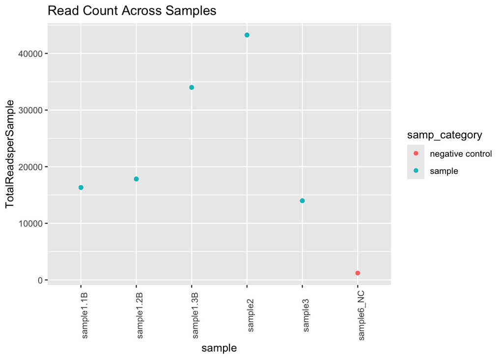

```r
plot_1 <- merged_table_long_v2 %>%
  filter(if(config_file$region == "18Sv4") samp_category != "positive control" else TRUE) %>%
  group_by(sample) %>%
  mutate(TotalReadsperSample = sum(reads)) %>%
  arrange(desc(TotalReadsperSample)) %>%
  ggplot(., aes(x = sample, y = TotalReadsperSample, color = samp_category)) +
  geom_point() +
  ggtitle("Read Count Across Samples") +
  theme(axis.text.x = element_text(angle = 90))

plot_1
```

```r
ggsave(
  plot = plot_1,
  here(config_file$output_path,config_file$region,"Output_plots","step2_Sample_Read_Depth_Barcode_1.png"),
  device = "png",
  width = 12,
  height = 8,
  units = "in"
)
```

#### Visualize Read Counts Across sample types

| Sample Type | Mean | SD | Max | Min | Median | n |
| --- | --- | --- | --- | --- | --- | --- |
| negative control | 1210 | NA | 1210 | 1210 | 1210 | 1 |
| sample | 25080 | 12863 | 43251 | 13990 | 17827 | 5 |

#### ASVs in positive controls

Beginning of code below will skip analysis if there are no positive controls present in the data.

#### ASVs in negative controls.

Beginning of code below will skip analysis if there are no negative controls present in the data.

#### Generate nested ASV table

```
## [[1]]
## # A tibble: 3 × 3
##   Stage  Stat     number
##   <chr>  <chr>     <dbl>
## 1 Step_0 nsamples      5
## 2 Step_0 nHashes      12
## 3 Step_0 nReads   125400
```

### 2.2: Model the composition of the positive controls of each run

### 2.3: Subtract the composition of the positive controls from the environment samples

- This is done ASV by ASV
- This could be translated to take the highest rate of index hopping observed for any non-positive control ASV and applied across all ASVs

```
## [[1]]
## # A tibble: 6 × 3
##   Stage       Stat     number
##   <chr>       <chr>     <dbl>
## 1 Step_0      nsamples      5
## 2 Step_0      nHashes      12
## 3 Step_0      nReads   125400
## 4 Step_1_Jump nsamples      5
## 5 Step_1_Jump nHashes      12
## 6 Step_1_Jump nReads   125400
```

## Step 3: Remove negative control contaminants

### Step 3.1: Investigate contaminants found in negative controls.

```
## # A tibble: 2 × 10
##   seq_id      sum_reads_neg Domain Phylum Class Order Family Genus Species Taxon
##   <chr>               <dbl> <chr>  <chr>  <chr> <chr> <chr>  <chr> <chr>   <chr>
## 1 767143ab9a…          1200 Eukar… Cnida… Hydr… Lept… Clyti… Clyt… Clytia… Euka…
## 2 05cde226a7…            10 Eukar… Dinop… Dino… NA    NA     NA    NA      Euka…
```

### Step 3.3: Which species are in the blanks and what are their occurrences & read counts

Calculate across all sequence id’s

Blanks and negative controls

```
## # A tibble: 10 × 4
##    seq_id   tot_reads_without_ne…¹ mean_reads_without_n…² occurrences_without_…³
##    <fct>                     <dbl>                  <dbl>                  <int>
##  1 20ae4af…                  30000                  30000                      1
##  2 79544ff…                    430                    108                      4
##  3 7e044ff…                  26475                   5295                      5
##  4 a92ff01…                   6900                   1380                      5
##  5 c3274ef…                     52                     26                      2
##  6 c6ab745…                   3350                    670                      5
##  7 c6fd437…                   5400                   1080                      5
##  8 da4854c…                   5900                   1180                      5
##  9 df07fc1…                  14350                   2870                      5
## 10 e9cb747…                   5000                   1000                      5
## # ℹ abbreviated names: ¹tot_reads_without_negASVs, ²mean_reads_without_negASVs,
## #   ³occurrences_without_negASVs
```

Plot of negative controls counts

Create negative control dataframes for filtering

### Step 3.4 option A: Format and run for microDecon

Format dataframe for (microDecontam)[https://github.com/donaldtmcknight/microDecon]

Run microdecontam with associated samples

Run microdecontam across all samples if no associated samples provided

Final Cleanup: Add to ASV_nested and ASV_summary

### Step 3.4 option B: Filter negative controls by proportion

- If more than one negative control associated with samples, get the mean proportions and use that for each seq_id in each sample

Run proportion filtering across all samples if no associated samples provided

Final Cleanup: Add to ASV_nested and ASV_summary

### Step 3.4 option C: Filter any ASVs found in negative controls

- If more than one negative control associated with samples, remove any asvs that showed up in any blanks

Run proportion filtering across all samples if no associated samples provided

Final Cleanup: Add to ASV_nested and ASV_summary

### Step 3.5 No negative control filtering

Save step2 dataframe as step3_tibble, for next steps of filtering.

```
## [[1]]
## # A tibble: 9 × 3
##   Stage          Stat     number
##   <chr>          <chr>     <dbl>
## 1 Step_0         nsamples      5
## 2 Step_0         nHashes      12
## 3 Step_0         nReads   125400
## 4 Step_1_Jump    nsamples      5
## 5 Step_1_Jump    nHashes      12
## 6 Step_1_Jump    nReads   125400
## 7 Step_3_no.filt nsamples      5
## 8 Step_3_no.filt nHashes      12
## 9 Step_3_no.filt nReads   125400
```

### Step 3.6 Create Sample associated negative control flag:

Add sample_nc_flag to step3_tibble

## Step 4: Remove the positive and negative control samples.

This is already done in the nested file format (Step3_tibble does not have negative controls)

## Step 5: Cleaning Process 2: **Remove Likely Lab Contaminants**

- Step 5.1: Remove any likely lab contaminants
- Step 5.2: Filter reads by length (if 12S non-target seqs included)
- Step 5.3: Remove off-target domains

### Step 5.1 Remove known lab contaminants

```
## # A tibble: 2 × 12
##   sample     seq_id   reads Domain Phylum Class Order Family Genus Species Taxon
##   <chr>      <chr>    <dbl> <chr>  <chr>  <chr> <chr> <chr>  <chr> <chr>   <chr>
## 1 sample1.1B c3274ef…     2 Eukar… Bacil… Baci… Navi… Diade… Luti… Lutico… Euka…
## 2 sample2    c3274ef…    50 Eukar… Bacil… Baci… Navi… Diade… Luti… Lutico… Euka…
## # ℹ 1 more variable: known_contaminant <lgl>
```

```
## [[1]]
## # A tibble: 12 × 3
##    Stage                  Stat     number
##    <chr>                  <chr>     <dbl>
##  1 Step_0                 nsamples      5
##  2 Step_0                 nHashes      12
##  3 Step_0                 nReads   125400
##  4 Step_1_Jump            nsamples      5
##  5 Step_1_Jump            nHashes      12
##  6 Step_1_Jump            nReads   125400
##  7 Step_3_no.filt         nsamples      5
##  8 Step_3_no.filt         nHashes      12
##  9 Step_3_no.filt         nReads   125400
## 10 Step_5_labcontaminants nsamples      5
## 11 Step_5_labcontaminants nHashes      11
## 12 Step_5_labcontaminants nReads   125348
```

### Step 5.2 filter by sequence length

- Filter out by length if indicated in config file (seq_length_filt==“Yes”)
  - seq_length_max indicates how to filter

Create dataframe of ASVs to remove:

```
## No sequence length filtering needed
```

### Step 5.3: Remove off-target domains

- 12S: ‘Bacteria’,‘Archaea’
- 18Sv4/18Sv9: ‘Bacteria’,‘Archaea’
- COI: ‘Bacteria’,‘Archaea’
- 16Sv4:
- ITS1: ‘Bacteria’,‘Archaea’

Create dataframe of these off-target taxa:

```r
# Domains to filter out:
metabar_off_target<-data.frame(
                        metabar_region = c("12S","12S","18Sv4","18Sv4","18Sv9","18Sv9",
                                           "COI","COI","ITS1","ITS1"),
                        Domain=c("Bacteria","Archaea","Bacteria","Archaea","Bacteria","Archaea",
                                 "Bacteria","Archaea","Bacteria","Archaea")) %>%
  filter(metabar_region==config_file$region)
# Taxonomy to filter everything else out by:
metabar_taxa_only<-data.frame(metabar_region = "12S", taxa_level= "Phylum", taxa_id="Chordata") %>%
  filter(metabar_region==config_file$region)
```

Filter out off-target based on region:

```
## Starting from Step5_remove_known_contaminants_tibble
```

Add to ASV_summary file:

```
## [[1]]
## # A tibble: 15 × 3
##    Stage                  Stat     number
##    <chr>                  <chr>     <dbl>
##  1 Step_0                 nsamples      5
##  2 Step_0                 nHashes      12
##  3 Step_0                 nReads   125400
##  4 Step_1_Jump            nsamples      5
##  5 Step_1_Jump            nHashes      12
##  6 Step_1_Jump            nReads   125400
##  7 Step_3_no.filt         nsamples      5
##  8 Step_3_no.filt         nHashes      12
##  9 Step_3_no.filt         nReads   125400
## 10 Step_5_labcontaminants nsamples      5
## 11 Step_5_labcontaminants nHashes      11
## 12 Step_5_labcontaminants nReads   125348
## 13 Step_5_offTarget       nsamples      5
## 14 Step_5_offTarget       nHashes      11
## 15 Step_5_offTarget       nReads   125348
```

## Final formatting of files before moving to Part II

#### Software and package versions used for file: